# Untitled

Shariq Mian

1/30/2023

## Overview

This is a banking and marketing dataset that was created by Sérgio Moro (ISCTE-IUL), Paulo Cortez (Univ. Minho) and Paulo Rita (ISCTE-IUL).It is a binary classification problem with the goal of predicting if the client will subscribe a bank term deposit (variable y).

[output not shown]

[output not shown]

## Data Exploration

This dataset consist of 11 character variables and 10 numeric variables. There are no missing values.

| skim_variable | n_missing | complete_rate | numeric.mean | numeric.sd |
| --- | --- | --- | --- | --- |
| job | 0 | 1 | NA | NA |
| marital | 0 | 1 | NA | NA |
| education | 0 | 1 | NA | NA |
| default | 0 | 1 | NA | NA |
| housing | 0 | 1 | NA | NA |
| loan | 0 | 1 | NA | NA |
| contact | 0 | 1 | NA | NA |
| month | 0 | 1 | NA | NA |
| day_of_week | 0 | 1 | NA | NA |
| poutcome | 0 | 1 | NA | NA |
| y | 0 | 1 | NA | NA |
| age | 0 | 1 | 40.0274190 | 10.4320921 |
| duration | 0 | 1 | 259.0187757 | 260.5061542 |
| campaign | 0 | 1 | 2.5591273 | 2.7619762 |
| pdays | 0 | 1 | 962.1262180 | 187.7785545 |
| previous | 0 | 1 | 0.1741931 | 0.4988711 |
| emp.var.rate | 0 | 1 | 0.0836878 | 1.5702098 |
| cons.price.idx | 0 | 1 | 93.5779597 | 0.5793179 |
| cons.conf.idx | 0 | 1 | -40.5246998 | 4.6162954 |
| euribor3m | 0 | 1 | 3.6237152 | 1.7332399 |
| nr.employed | 0 | 1 | 5167.1613577 | 72.1747491 |

### Balance

The difference between those not enrolling into the services and those that due is heavily imbalanced. This will make predicting those that enroll more difficult.

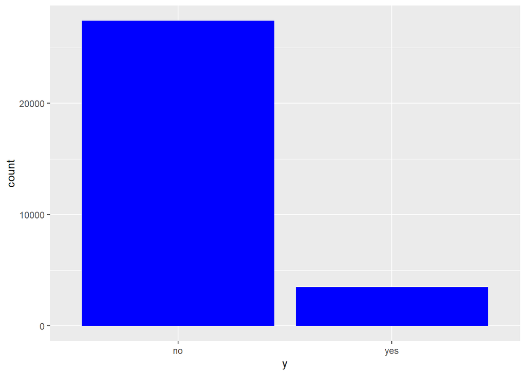

### Unique Values in Numeric Fields

From the unique values in the numeric fields we can see that several variables can be grouped. Such as cons.price.idx and cons.conf.idx. The previous variable looks like it should either be grouped as 0’s and 1’s signifying previous conversations or simply factored into groups of the number of conversations.

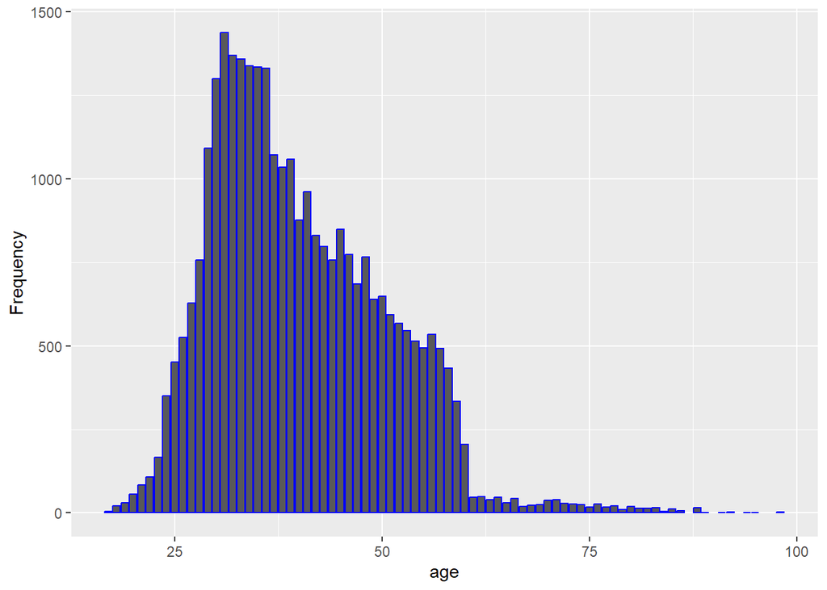

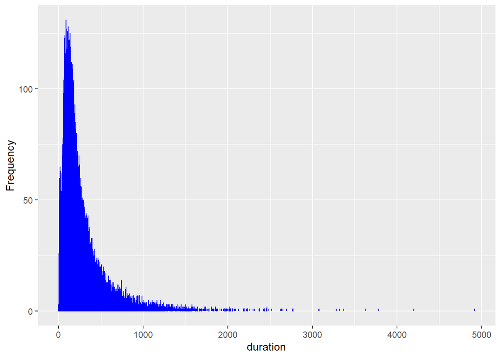

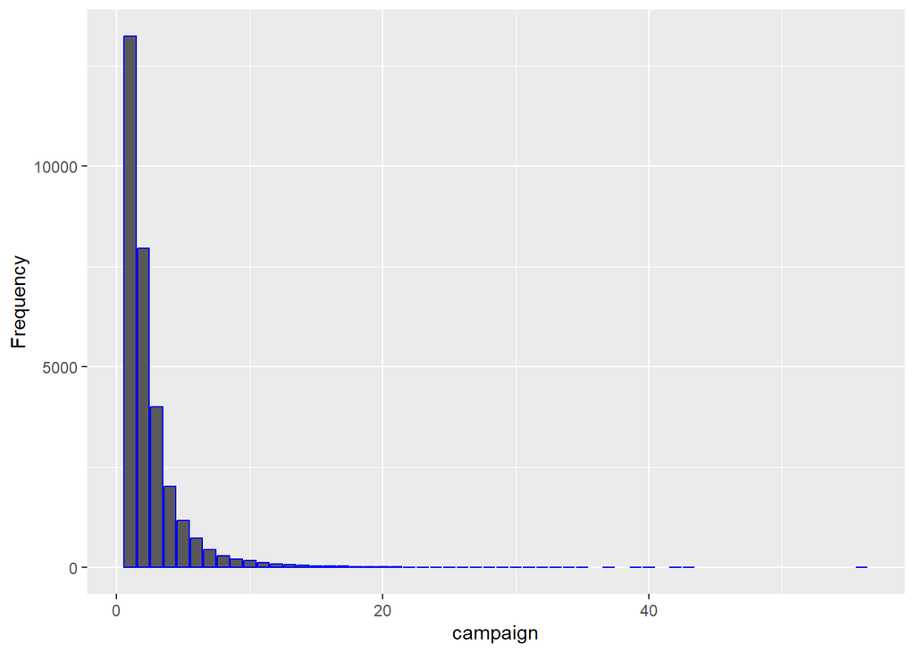

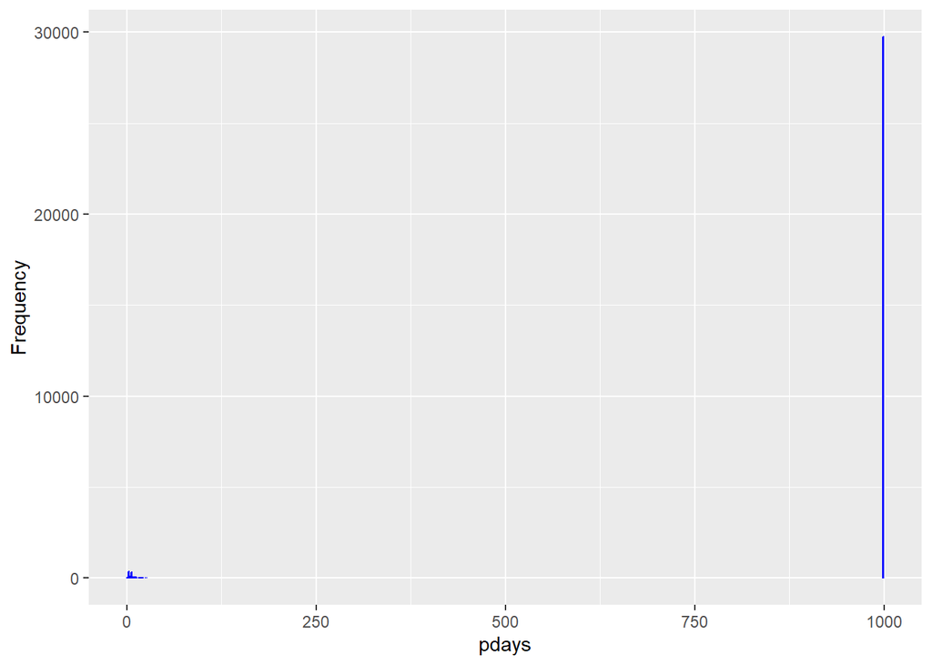

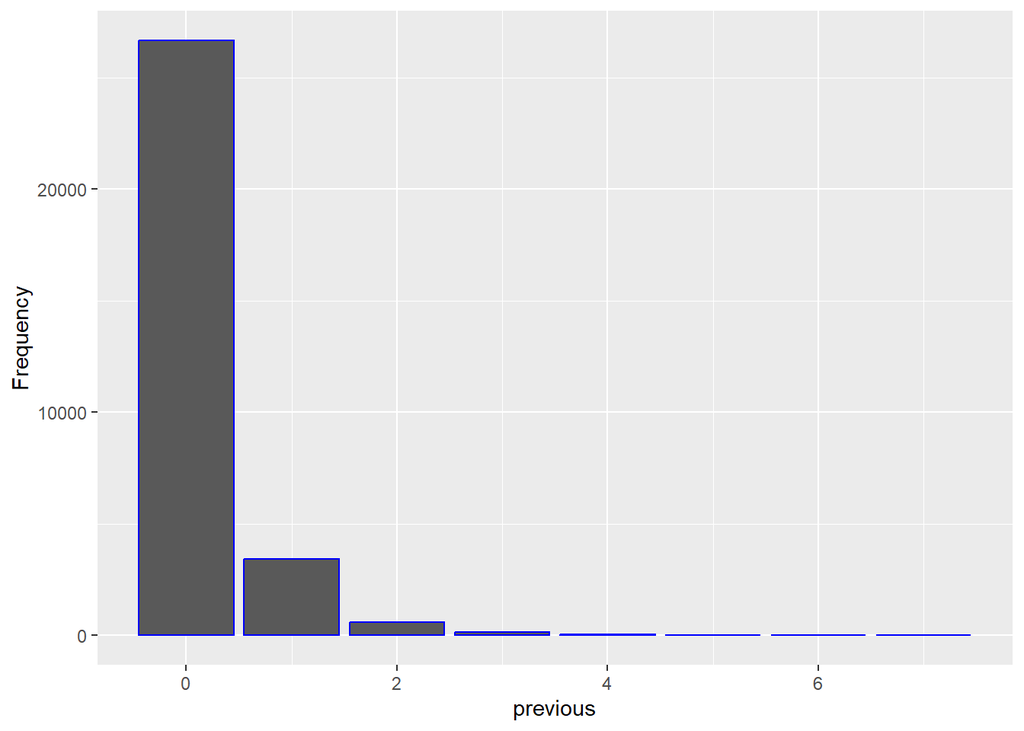

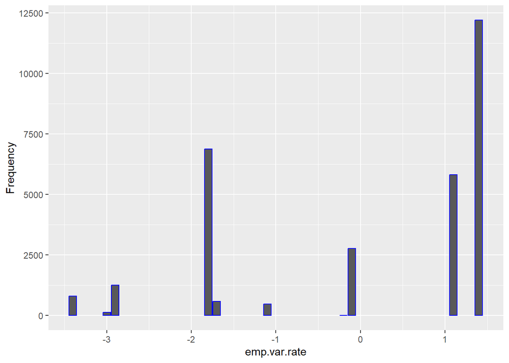

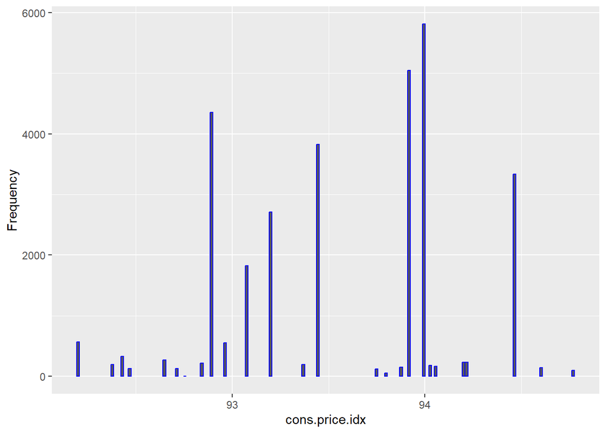

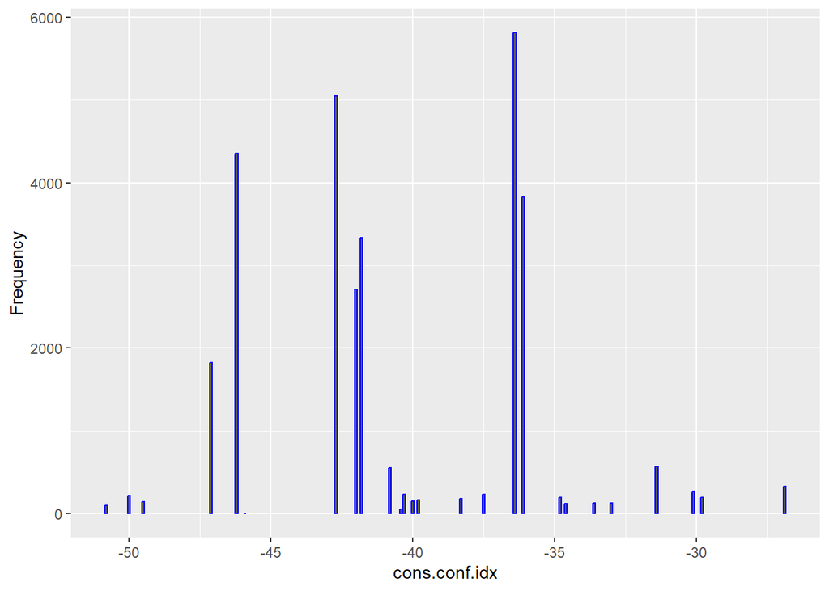

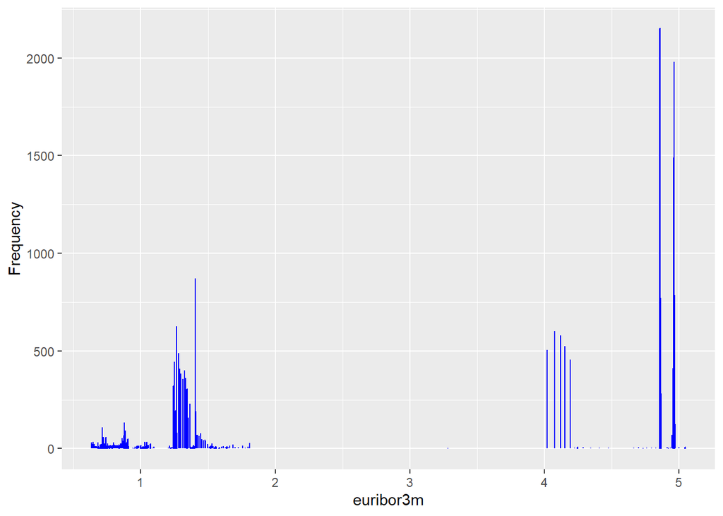

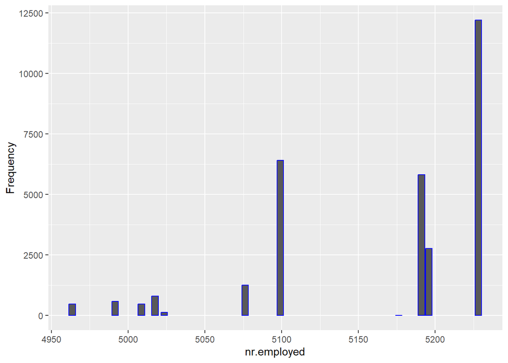

### Correlations

From the correlation plot we can see that the emp.var.rate variable is highly correlated to three other variables, cons.price.idx, euribor3m and nr.employed. We also see that euribor3m and nr.employed are highly correlated with each other.

Due to this correlation both the emp.var.rate and euribor3m variables should be removed to limit the risk of multicollinearity.

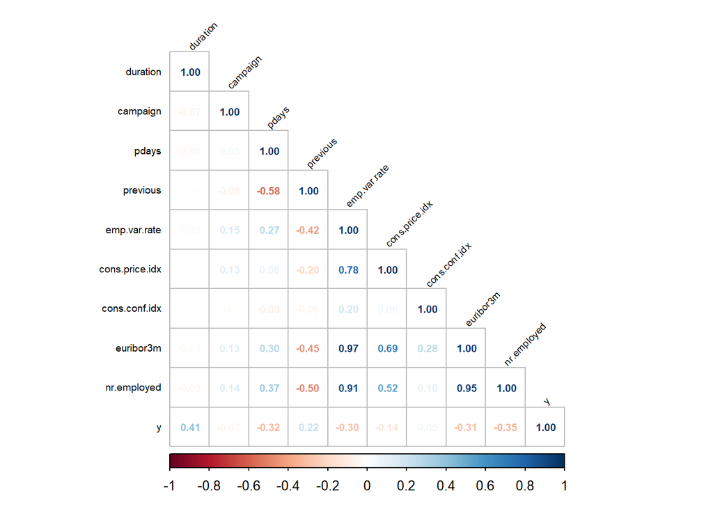

## Data Preparation

### Remove correlated variables

```r
og_training <- subset(og_training, select=-c(emp.var.rate, euribor3m))

og_testing <- subset(og_testing, select=-c(emp.var.rate, euribor3m))
```

### Turn y from ‘no’/‘yes’ to 0,1

```r
og_training$y <- ifelse(og_training$y == "no",0,1)

og_testing$y <- ifelse(og_testing$y == "no",0,1)
```

### Grouping

The cons.price.idx variable has a range from 92.2 to 94.77. The histogram shows us that groups from 92 to 93, 93 to 94 and everything greater than 94, should be a relatively normal looking distribution of variables.

```
##    Min. 1st Qu.  Median    Mean 3rd Qu.    Max.
##   92.20   93.08   93.80   93.58   93.99   94.77
```

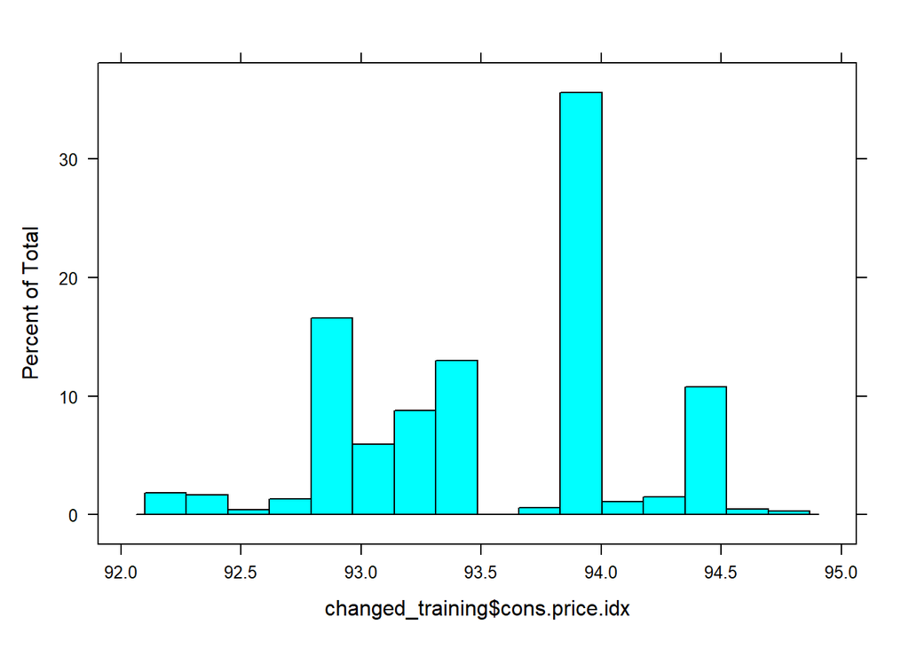

```r
changed_training$cons_price_group <- ifelse(as.numeric(changed_training$cons.price.idx) >= 94,2,ifelse(as.numeric(changed_training$cons.price.idx) <94 & as.numeric(changed_training$cons.price.idx) >=93,1,0))
changed_training$cons_price_group <- as.character(changed_training$cons_price_group)



changed_testing <- og_testing
changed_testing$cons_price_group <- ifelse(as.numeric(changed_testing$cons.price.idx) >= 94,2,ifelse(as.numeric(changed_testing$cons.price.idx) <94 & as.numeric(changed_testing$cons.price.idx) >=93,1,0))
changed_testing$cons_price_group <- as.character(changed_testing$cons_price_group)
```

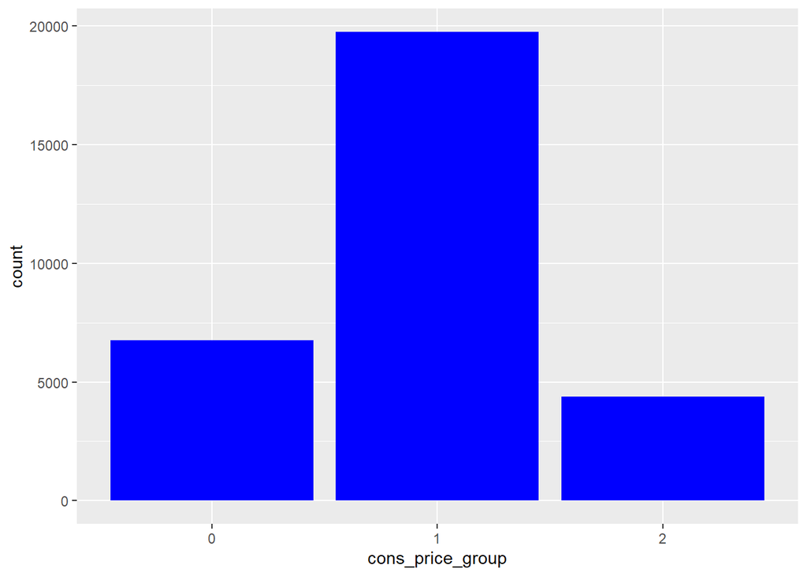

```
##    Min. 1st Qu.  Median    Mean 3rd Qu.    Max.
##  -50.80  -42.70  -41.80  -40.52  -36.40  -26.90
```

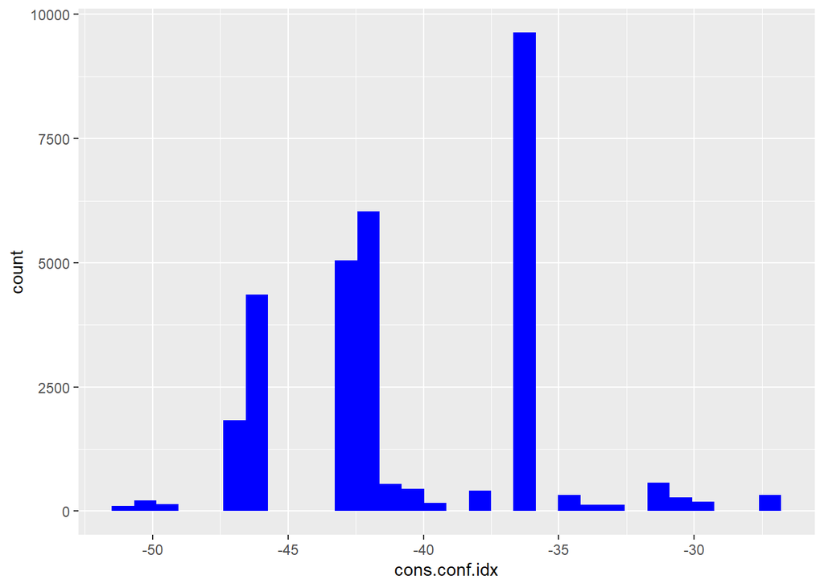

```r
changed_training$cons_confs_group <- ifelse(as.numeric(changed_training$cons.conf.idx) <= (-45),3,ifelse(as.numeric(changed_training$cons.conf.idx) >= -45 & as.numeric(changed_training$cons.conf.idx)<=(-40),2, ifelse(as.numeric(changed_training$cons.conf.idx) >= -40 & as.numeric(changed_training$cons.conf.idx)<=(-35),1,0)))
changed_training$cons_confs_group <- as.character(changed_training$cons_confs_group)

changed_testing$cons_confs_group <- ifelse(as.numeric(changed_testing$cons.conf.idx) <= (-45),3,ifelse(as.numeric(changed_testing$cons.conf.idx) >= -45 & as.numeric(changed_testing$cons.conf.idx)<=(-40),2, ifelse(as.numeric(changed_testing$cons.conf.idx) >= -40 & as.numeric(changed_testing$cons.conf.idx)<=(-35),1,0)))
changed_testing$cons_confs_group <- as.character(changed_testing$cons_confs_group)
```

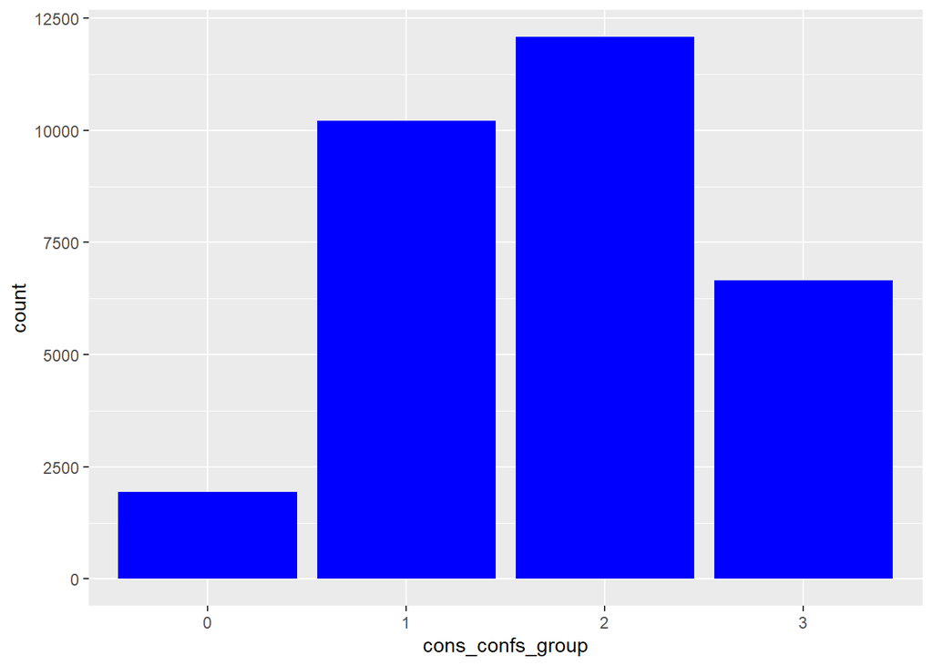

### Factoring

All the character variables will be turned into dummy variables for each respective level in the group.

```r
library(tidytable)
dummy <- get_dummies(changed_training)
dummy <- subset(dummy,select=-c(job,marital,education,default,housing,loan,contact,month,day_of_week,poutcome,previous,cons.conf.idx,cons.price.idx,cons_confs_group,cons_price_group))
remove(changed_training)

dummy_testing <- get_dummies.(changed_testing)
dummy_testing <- subset(dummy_testing,select=-c(job,marital,education,default,housing,loan,contact,month,day_of_week,poutcome,previous,cons.conf.idx,cons.price.idx,cons_confs_group,cons_price_group))
remove(changed_testing)
```

There have been problems with the variables not matching between the training and testing data. With identical I can test to make sure that all the variables are the same in both datasets.

```r
identical(names(dummy),names(dummy_testing))
```

```
## [1] FALSE
```

### Unbalance

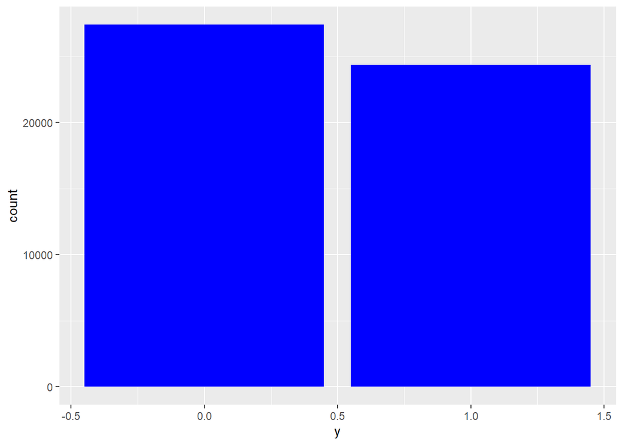

```r
ggplot(dummy_smote$data,aes(x=y))+
  geom_histogram(stat='count',fill='blue')
```

### Training and Testing sets

```r
set.seed(93384)
trainIndex <- createDataPartition(dummy_smote$data$y, p = .65,
                                  list = FALSE,
                                  times = 1,

                                  )

ftrain <-dummy_smote$data[trainIndex,]
ftrain <- subset(ftrain, select=-c(class))
ftest <- dummy_smote$data[-trainIndex,]
ftest <- subset(ftest, select=-c(class))


train <- xgb.DMatrix(data = data.matrix(ftrain[,-c(6)]), label = ftrain$y)

validate <- xgb.DMatrix(data = data.matrix(ftest[,-c(6)]), label = ftest$y)

t_label <- dummy_testing$y
true_test <- xgb.DMatrix(data = data.matrix(dummy_testing[,-c(6)]), label = t_label)
```

```r
identical(names(ftrain),names(dummy_testing))
```

```
## [1] FALSE
```

## Building Models

### Model 1 GLM basic

```r
glm_ini <- glm(y ~ ., ftrain,family='binomial')
summary(glm_ini)
```

```
##
## Call:
## glm(formula = y ~ ., family = "binomial", data = ftrain)
##
## Deviance Residuals:
##     Min       1Q   Median       3Q      Max
## -8.4904  -0.3793  -0.1460   0.4776   3.0082
##
## Coefficients: (12 not defined because of singularities)
##                                 Estimate Std. Error z value Pr(>|z|)
## (Intercept)                    1.197e+11  1.542e+12   0.078 0.938139
## age                           -1.551e-03  2.190e-03  -0.708 0.478918
## duration                       6.959e-03  8.814e-05  78.950  < 2e-16 ***
## campaign                      -7.011e-02  1.111e-02  -6.313 2.73e-10 ***
## pdays                         -8.546e-04  2.305e-04  -3.707 0.000210 ***
## nr.employed                   -1.607e-02  5.020e-04 -32.017  < 2e-16 ***
## job_admin.                    -5.477e-01  2.333e-01  -2.348 0.018894 *
## `job_blue-collar`             -8.227e-01  2.357e-01  -3.491 0.000482 ***
## job_entrepreneur              -7.674e-01  2.518e-01  -3.048 0.002307 **
## job_housemaid                 -4.787e-01  2.600e-01  -1.841 0.065619 .
## job_management                -7.082e-01  2.405e-01  -2.945 0.003234 **
## job_retired                   -1.097e-01  2.441e-01  -0.449 0.653195
## `job_self-employed`           -9.077e-01  2.529e-01  -3.590 0.000331 ***
## job_services                  -6.134e-01  2.393e-01  -2.563 0.010362 *
## job_student                   -3.373e-01  2.530e-01  -1.333 0.182462
## job_technician                -6.127e-01  2.362e-01  -2.595 0.009471 **
## job_unemployed                -3.042e-01  2.548e-01  -1.194 0.232463
## job_unknown                           NA         NA      NA       NA
## marital_divorced              -3.489e-01  3.947e-01  -0.884 0.376685
## marital_married               -2.479e-01  3.910e-01  -0.634 0.526035
## marital_single                -2.079e-01  3.917e-01  -0.531 0.595586
## marital_unknown                       NA         NA      NA       NA
## education_basic.4y            -3.092e-01  1.168e-01  -2.646 0.008139 **
## education_basic.6y            -8.987e-02  1.310e-01  -0.686 0.492742
## education_basic.9y            -2.131e-01  1.104e-01  -1.931 0.053468 .
## education_high.school         -1.775e-01  1.025e-01  -1.731 0.083481 .
## education_illiterate           2.943e-01  8.039e-01   0.366 0.714247
## education_professional.course  7.943e-02  1.111e-01   0.715 0.474556
## education_university.degree    1.180e-01  1.018e-01   1.159 0.246486
## education_unknown                     NA         NA      NA       NA
```

[output cut: 31 more lines]

```
## cons_price_group_2                    NA         NA      NA       NA
## cons_confs_group_0             9.579e-02  1.067e-01   0.898 0.369105
## cons_confs_group_1             1.020e+00  1.585e-01   6.435 1.23e-10 ***
## cons_confs_group_2             1.969e+00  1.642e-01  11.992  < 2e-16 ***
## cons_confs_group_3                    NA         NA      NA       NA
## ---
## Signif. codes:  0 '***' 0.001 '**' 0.01 '*' 0.05 '.' 0.1 ' ' 1
##
## (Dispersion parameter for binomial family taken to be 1)
##
##     Null deviance: 46544  on 33651  degrees of freedom
## Residual deviance: 21797  on 33598  degrees of freedom
## AIC: 21905
##
## Number of Fisher Scoring iterations: 25
```

```r
pred_glm <- predict(glm_ini, ftest,type='response')
```

### Ideal Binomial Threshold function

Since the binomial regression produces an estimation of probability, it is important to find the threshold that produces the best overall results.

There is much debate about which statistics from the confusion matrix is the best at determining model quality. In my opinion the best model would predict the ratio of true positives and ratio of true negatives equally well. As it limits the cost of being wrong.

The purpose of the ideal_binomial_threshold function is to find the threshold value that returns the smallest difference between the sensitivity and the specificity. This difference signifies the threshold value that balances the ratios of true positive predictions and the true negative predictions. Thus informing us of the threshold that determines the most balanced predictive power of the model.

```r
ideal_binomial_threshold <- function(predictions,y){

  thresholds <- data.frame(matrix(ncol=8,nrow=501))
  colnames(thresholds) <- c('Threshold','Balanced_Accuracy','Sensitivity','Specificity',
                            'Sen_Spec_Diff')
  index=1

  for(i in seq(.25,.75,.001)){

      binom <- ifelse(predictions>i,1,0)
      cM <- confusionMatrix(as.factor(binom),as.factor(y))

      thresholds$Threshold[index] <- i
      thresholds$Balanced_Accuracy[index] <- as.numeric(cM$byClass['Balanced Accuracy'])
      thresholds$Sensitivity[index] <-as.numeric(cM$byClass['Sensitivity'])
      thresholds$Specificity[index] <-as.numeric(cM$byClass['Specificity'])
      sen<- as.numeric(cM$byClass['Sensitivity'])
      spec <- as.numeric(cM$byClass['Specificity'])
      sen_spec_diff <- ifelse(sen>= spec,(sen-spec), (spec-sen))
      thresholds$Sen_Spec_Diff[index] <- sen_spec_diff
      index <- index+1
  }

  min_thresh <- thresholds[which.min(thresholds$Sen_Spec_Diff),]
  return(min_thresh)
}

thresh <- ideal_binomial_threshold(pred_glm,ftest$y)
thresh
```

```
##     Threshold Balanced_Accuracy Sensitivity Specificity Sen_Spec_Diff NA NA NA
## 255     0.504         0.8733997   0.8732877   0.8735117  0.0002240581 NA NA NA
```

```r
pred_glm_ideal <- ifelse(pred_glm >thresh$Threshold[1],1,0)
cM <- confusionMatrix(factor(pred_glm_ideal),factor(ftest$y))
cM
```

```
## Confusion Matrix and Statistics
##
##           Reference
## Prediction    0    1
##          0 8415 1073
##          1 1221 7410
##
##                Accuracy : 0.8734
##                  95% CI : (0.8685, 0.8782)
##     No Information Rate : 0.5318
##     P-Value [Acc > NIR] : < 2.2e-16
##
##                   Kappa : 0.746
##
##  Mcnemar's Test P-Value : 0.002147
##
##             Sensitivity : 0.8733
##             Specificity : 0.8735
##          Pos Pred Value : 0.8869
##          Neg Pred Value : 0.8585
##              Prevalence : 0.5318
##          Detection Rate : 0.4644
##    Detection Prevalence : 0.5236
##       Balanced Accuracy : 0.8734
##
##        'Positive' Class : 0
##
```

### GLM Model 1 Analysis

With a threshold of 0.504 the model has a balanced accuracy score of 0.8733997. The AIC score is 2.1905262^{4}.

## Tuning the XGBoost Parameters

In order for the xgboost model to work at its maximum ability several parameters need to be selected. To select the ideal parameters caret has a package that tunes the parameters, which gives the best parameter set up.

### Initial Parameters

To get a rough idea of the nrounds needed to be used the xgb.cv function will be used with a basic parameters set up.We will test a maximum of 1500 rounds.

```r
params <- list(

  booster            = "gbtree",

  eta                = 0.1,

  max_depth          = 5,

  gamma              = 0,

  subsample          = 1,

  colsample_bytree   = 1,

  colsample_bylevel  = 1,

  min_child_weight   = 1,

  objective          ="binary:logistic",   #

  eval_metric        = "error"

)

xgbcv <- xgb.cv( params = params, data = train, nrounds = 1500, nfold=5, print_every_n = 100, early_stop_rounds = 1000,verbose=0)
```

```r
min_error = min(xgbcv$evaluation_log[, test_error_mean])
min_error_index = which.min(xgbcv$evaluation_log[, test_error_mean])
print(min_error)
```

```
## [1] 0.05170574
```

```r
print(min_error_index)
```

```
## [1] 137
```

The basic parameters shows us that the number of nrounds should be around 137

### In depth Tuning

With the caret package you can tune all the parameters at the same time, but for each choice given, the time it takes to return a tuning is increased.

```r
tune_grid <- expand.grid(
  nrounds = as.numeric(min_error_index),
  max_depth = c(4,7,10),
  eta = c(.05,.1,0.3),
  colsample_bytree = .75,
  subsample = .9,
  gamma = c(0,1,5),
  min_child_weight =1
)
```

```r
xgb_tune <- train(
  x = ftrain[,-c(6)],
  y = factor(ftrain$y),
  trControl = tune_control,
  tuneGrid = tune_grid,
  method = "xgbTree",
  verbose = 0
)
```

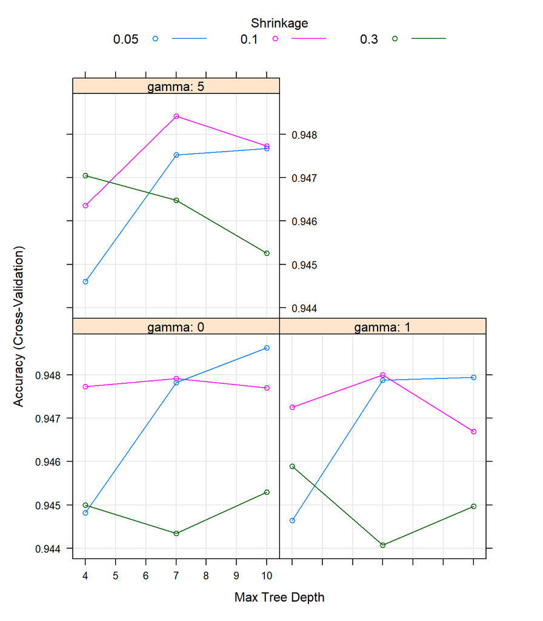

```r
plot(xgb_tune)
```

### Best Tune

The bestTune variable of the xgb_tune will give us the best tuned parameters.

```r
xgb_tune$bestTune
```

```
##   nrounds max_depth  eta gamma colsample_bytree min_child_weight subsample
## 7     137        10 0.05     0             0.75                1       0.9
```

```r
tuned_params<- list(

  booster            = "gbtree",

  eta                = xgb_tune$bestTune$eta,

  max_depth          = xgb_tune$bestTune$max_depth,

  gamma             = xgb_tune$bestTune$gamma,

  subsample          = xgb_tune$bestTune$subsample,

  colsample_bytree   = xgb_tune$bestTune$colsample_bytree,


  min_child_weight   = xgb_tune$bestTune$min_child_weight,


  objective          ="binary:logistic",   #

  eval_metric        = "error"

)

xgbcv2 <- xgb.cv( params = params, data = train, nrounds = as.numeric(min_error_index), nfold=5, print_every_n = 100, early_stop_rounds = 1000)
min_error2 = min(xgbcv2$evaluation_log[, test_error_mean])
min_error_index2 = which.min(xgbcv2$evaluation_log[, test_error_mean])
print(min_error)
```

```
## [1] 0.05170574
```

```r
print(min_error_index)
```

```
## [1] 137
```

```r
xgb_model <- xgb.train(tuned_params, train, nrounds = as.numeric(min_error_index))
```

```r
xgb_pred <- predict(xgb_model, validate)

thresh2 <- ideal_binomial_threshold(xgb_pred,ftest$y)
```

```r
xgb_pred_prob <- ifelse(xgb_pred >=thresh2$Threshold[1],1,0 )
```

```r
cM2<-confusionMatrix(as.factor(xgb_pred_prob),as.factor(ftest$y))
cM2
```

```
## Confusion Matrix and Statistics
##
##           Reference
## Prediction    0    1
##          0 9170  408
##          1  466 8075
##
##                Accuracy : 0.9518
##                  95% CI : (0.9485, 0.9548)
##     No Information Rate : 0.5318
##     P-Value [Acc > NIR] : < 2e-16
##
##                   Kappa : 0.9032
##
##  Mcnemar's Test P-Value : 0.05385
##
##             Sensitivity : 0.9516
##             Specificity : 0.9519
##          Pos Pred Value : 0.9574
##          Neg Pred Value : 0.9454
##              Prevalence : 0.5318
##          Detection Rate : 0.5061
##    Detection Prevalence : 0.5286
##       Balanced Accuracy : 0.9518
##
##        'Positive' Class : 0
##
```

### XGB Model Analysis

The xgboost model performed ~8% better than the glm models with a ~95% prediction rate. The sensitivity and specificity scores are both ~95%. All these scores are .43 points better than the no information rate. Both positive and negative prediction rates are ~95%.

```r
library(ggplot2)
library(scales)
```

```r
og_training1=og_training
```

```r
var_used<-og_training1[c("age","job","marital","education","housing")] #selecting the data for segmentation

customer1<-data.matrix(var_used[c("job","marital","education","housing")])

var_used<-data.frame(var_used,customer1) #Data Coversion
str(var_used)
```

```
## 'data.frame':    30891 obs. of  9 variables:
##  $ age        : int  57 37 40 45 41 24 25 41 25 29 ...
##  $ job        : chr  "services" "services" "admin." "services" ...
##  $ marital    : chr  "married" "married" "married" "married" ...
##  $ education  : chr  "high.school" "high.school" "basic.6y" "basic.9y" ...
##  $ housing    : chr  "no" "yes" "no" "no" ...
##  $ job.1      : int  8 8 1 8 2 10 8 2 8 2 ...
##  $ marital.1  : int  2 2 2 2 2 3 3 2 3 3 ...
##  $ education.1: int  4 4 2 3 8 6 4 8 4 4 ...
##  $ housing.1  : int  1 3 1 1 1 3 3 1 3 1 ...
```

```r
job<-unique(var_used[c("job","job.1")])

marital<-unique(var_used[c("marital","marital.1")])

education<-unique(var_used[c("education","education.1")])

housing<-unique(var_used[c("housing","housing.1")])
```

```r
x<-c("age","job.1","marital.1","education.1","housing.1")
```

```r
x
```

```
## [1] "age"         "job.1"       "marital.1"   "education.1" "housing.1"
```

```r
# Clustering Using K-Means

set.seed(100)

# K-meand Function to create 5 Cluster with 25 random scenario
segmentation<-kmeans(x=var_used[x], center=8, nstart=25)

# Analyze Cluster Size Output
og_training$cluster<-segmentation$cluster
```

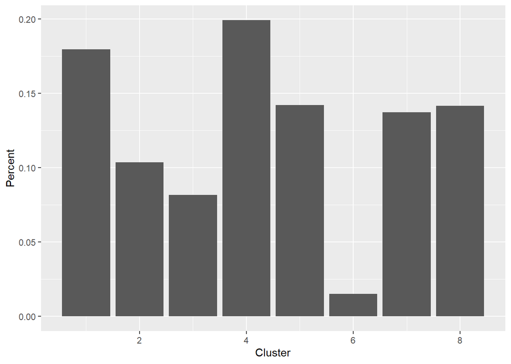

```r
pp <- ggplot(data=og_training, aes(x=cluster,fill=y)) +
      geom_bar(aes(y = (..count..)/sum(..count..)))

pp +  labs(x="Cluster", y = "Percent")
```

[figure not shown]

```r
var_used %>%
  as_tibble() %>%
  mutate(cluster = segmentation$cluster,
         state = row.names(USArrests)) %>%
  ggplot(aes(marital, education, color = factor(cluster), label = job)) +
  geom_text()
```

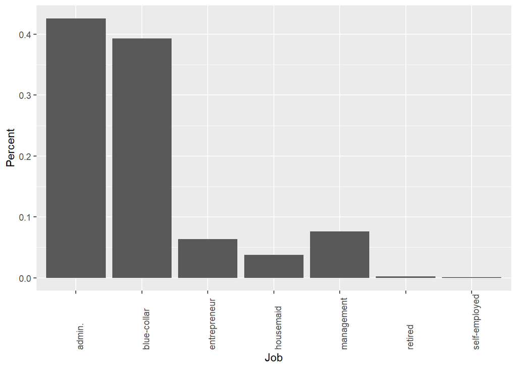

```r
datacharacteristics <-og_training[which(og_training$cluster == 4),]
a <- ggplot(data=datacharacteristics, aes(x=job)) +
      geom_bar(aes(y = (..count..)/sum(..count..)))

a +  labs(x="Job", y = "Percent") +theme(axis.text.x = element_text(angle=90,hjust = 0))
```

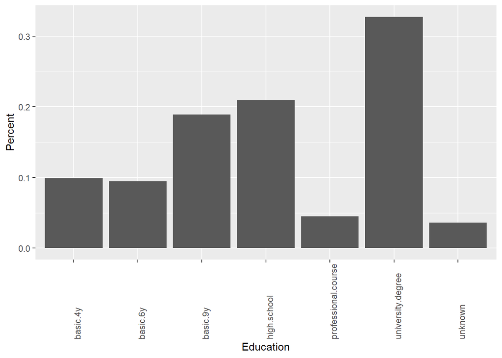

```r
b <- ggplot(data=datacharacteristics, aes(x=education)) +
      geom_bar(aes(y = (..count..)/sum(..count..)))

b +  labs(x="Education", y = "Percent") +theme(axis.text.x = element_text(angle=90,hjust = 0))
```

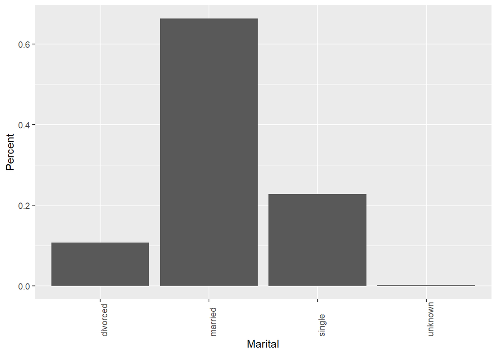

```r
# Marital Status

c <- ggplot(data=datacharacteristics, aes(x=marital)) +
      geom_bar(aes(y = (..count..)/sum(..count..)))

c +  labs(x="Marital", y = "Percent") +theme(axis.text.x = element_text(angle=90,hjust = 0))
```

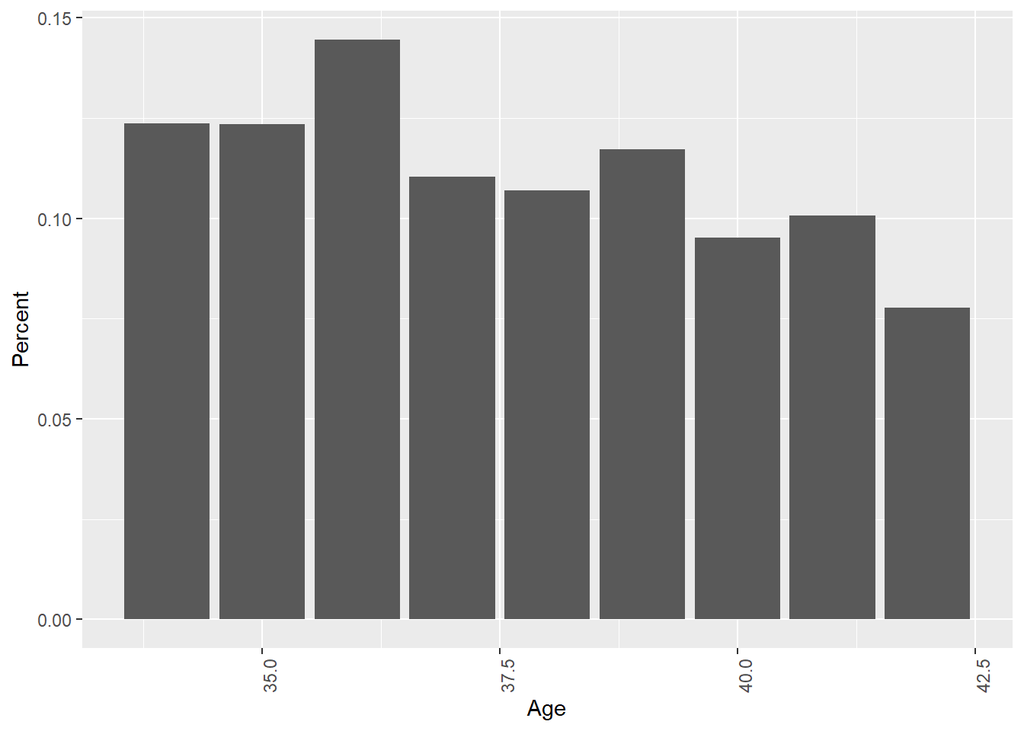

```r
# Age

d <- ggplot(data=datacharacteristics, aes(x=age)) +
      geom_bar(aes(y = (..count..)/sum(..count..)))

d +  labs(x="Age", y = "Percent") +theme(axis.text.x = element_text(angle=90,hjust = 0))
```

## Citations

[Moro et al., 2014] S. Moro, P. Cortez and P. Rita. A Data-Driven Approach to Predict the Success of Bank Telemarketing. Decision Support Systems, In press, http://dx.doi.org/10.1016/j.dss.2014.03.001